# Risk Factor Analysis

## Outcome Variable

**Outcome Variable:** whz

## Predictor Variables

**Intervention Variable:** mage

**Adjustment Set:**

- arm
- meducyrs
- feducyrs
- W_mhtcm
- single
- impsan
- W_gagebrth
- W_birthwt
- W_birthlen
- vagbrth
- parity
- delta_meducyrs
- delta_feducyrs
- delta_W_mhtcm
- delta_single
- delta_impsan
- delta_W_gagebrth
- delta_W_birthwt
- delta_W_birthlen
- delta_vagbrth
- delta_parity

## Stratifying Variables

The analysis was stratified on these variable(s):

- agecat
- studyid
- country

## Data Summary

| agecat | studyid | country | mage | n_cell | n |
| --- | --- | --- | --- | --- | --- |
| 6 months | ki0047075b-MAL-ED | BANGLADESH | [20-30) | 165 | 241 |
| 6 months | ki0047075b-MAL-ED | BANGLADESH | <20 | 35 | 241 |
| 6 months | ki0047075b-MAL-ED | BANGLADESH | >=30 | 41 | 241 |
| 6 months | ki0047075b-MAL-ED | BRAZIL | [20-30) | 125 | 209 |
| 6 months | ki0047075b-MAL-ED | BRAZIL | <20 | 37 | 209 |
| 6 months | ki0047075b-MAL-ED | BRAZIL | >=30 | 47 | 209 |
| 6 months | ki0047075b-MAL-ED | INDIA | [20-30) | 179 | 234 |
| 6 months | ki0047075b-MAL-ED | INDIA | <20 | 34 | 234 |
| 6 months | ki0047075b-MAL-ED | INDIA | >=30 | 21 | 234 |
| 6 months | ki0047075b-MAL-ED | NEPAL | [20-30) | 185 | 236 |
| 6 months | ki0047075b-MAL-ED | NEPAL | <20 | 5 | 236 |
| 6 months | ki0047075b-MAL-ED | NEPAL | >=30 | 46 | 236 |
| 6 months | ki0047075b-MAL-ED | PERU | [20-30) | 136 | 273 |
| 6 months | ki0047075b-MAL-ED | PERU | <20 | 76 | 273 |
| 6 months | ki0047075b-MAL-ED | PERU | >=30 | 61 | 273 |
| 6 months | ki0047075b-MAL-ED | SOUTH AFRICA | [20-30) | 118 | 254 |
| 6 months | ki0047075b-MAL-ED | SOUTH AFRICA | <20 | 42 | 254 |
| 6 months | ki0047075b-MAL-ED | SOUTH AFRICA | >=30 | 94 | 254 |
| 6 months | ki0047075b-MAL-ED | TANZANIA, UNITED REPUBLIC OF | [20-30) | 128 | 247 |
| 6 months | ki0047075b-MAL-ED | TANZANIA, UNITED REPUBLIC OF | <20 | 15 | 247 |
| 6 months | ki0047075b-MAL-ED | TANZANIA, UNITED REPUBLIC OF | >=30 | 104 | 247 |
| 6 months | ki1000108-CMC-V-BCS-2002 | INDIA | [20-30) | 292 | 368 |
| 6 months | ki1000108-CMC-V-BCS-2002 | INDIA | <20 | 33 | 368 |
| 6 months | ki1000108-CMC-V-BCS-2002 | INDIA | >=30 | 43 | 368 |
| 6 months | ki1000108-IRC | INDIA | [20-30) | 342 | 408 |
| 6 months | ki1000108-IRC | INDIA | <20 | 37 | 408 |
| 6 months | ki1000108-IRC | INDIA | >=30 | 29 | 408 |
| 6 months | ki1000109-EE | PAKISTAN | [20-30) | 160 | 373 |
| 6 months | ki1000109-EE | PAKISTAN | <20 | 1 | 373 |
| 6 months | ki1000109-EE | PAKISTAN | >=30 | 212 | 373 |

[output cut: 114 more lines]

The following strata were considered:

- agecat: 24 months, studyid: ki0047075b-MAL-ED, country: BANGLADESH
- agecat: 24 months, studyid: ki0047075b-MAL-ED, country: BRAZIL
- agecat: 24 months, studyid: ki0047075b-MAL-ED, country: INDIA
- agecat: 24 months, studyid: ki0047075b-MAL-ED, country: NEPAL
- agecat: 24 months, studyid: ki0047075b-MAL-ED, country: PERU
- agecat: 24 months, studyid: ki0047075b-MAL-ED, country: SOUTH AFRICA
- agecat: 24 months, studyid: ki0047075b-MAL-ED, country: TANZANIA, UNITED REPUBLIC OF
- agecat: 24 months, studyid: ki1000108-CMC-V-BCS-2002, country: INDIA
- agecat: 24 months, studyid: ki1000108-IRC, country: INDIA
- agecat: 24 months, studyid: ki1017093-NIH-Birth, country: BANGLADESH
- agecat: 24 months, studyid: ki1017093b-PROVIDE, country: BANGLADESH
- agecat: 24 months, studyid: ki1017093c-NIH-Crypto, country: BANGLADESH
- agecat: 24 months, studyid: ki1066203-TanzaniaChild2, country: TANZANIA, UNITED REPUBLIC OF
- agecat: 24 months, studyid: ki1101329-Keneba, country: GAMBIA
- agecat: 24 months, studyid: ki1113344-GMS-Nepal, country: NEPAL
- agecat: 24 months, studyid: ki1119695-PROBIT, country: BELARUS
- agecat: 24 months, studyid: ki1126311-ZVITAMBO, country: ZIMBABWE
- agecat: 24 months, studyid: ki1135781-COHORTS, country: GUATEMALA
- agecat: 24 months, studyid: ki1135781-COHORTS, country: INDIA
- agecat: 24 months, studyid: ki1135781-COHORTS, country: PHILIPPINES
- agecat: 24 months, studyid: ki1148112-LCNI-5, country: MALAWI
- agecat: 24 months, studyid: kiGH5241-JiVitA-3, country: BANGLADESH
- agecat: 6 months, studyid: ki0047075b-MAL-ED, country: BANGLADESH
- agecat: 6 months, studyid: ki0047075b-MAL-ED, country: BRAZIL
- agecat: 6 months, studyid: ki0047075b-MAL-ED, country: INDIA
- agecat: 6 months, studyid: ki0047075b-MAL-ED, country: NEPAL
- agecat: 6 months, studyid: ki0047075b-MAL-ED, country: PERU
- agecat: 6 months, studyid: ki0047075b-MAL-ED, country: SOUTH AFRICA
- agecat: 6 months, studyid: ki0047075b-MAL-ED, country: TANZANIA, UNITED REPUBLIC OF
- agecat: 6 months, studyid: ki1000108-CMC-V-BCS-2002, country: INDIA
- agecat: 6 months, studyid: ki1000108-IRC, country: INDIA
- agecat: 6 months, studyid: ki1000109-EE, country: PAKISTAN
- agecat: 6 months, studyid: ki1000304b-SAS-CompFeed, country: INDIA
- agecat: 6 months, studyid: ki1000304b-SAS-FoodSuppl, country: INDIA
- agecat: 6 months, studyid: ki1017093-NIH-Birth, country: BANGLADESH
- agecat: 6 months, studyid: ki1017093b-PROVIDE, country: BANGLADESH
- agecat: 6 months, studyid: ki1017093c-NIH-Crypto, country: BANGLADESH
- agecat: 6 months, studyid: ki1066203-TanzaniaChild2, country: TANZANIA, UNITED REPUBLIC OF
- agecat: 6 months, studyid: ki1101329-Keneba, country: GAMBIA
- agecat: 6 months, studyid: ki1112895-Guatemala BSC, country: GUATEMALA
- agecat: 6 months, studyid: ki1113344-GMS-Nepal, country: NEPAL
- agecat: 6 months, studyid: ki1119695-PROBIT, country: BELARUS
- agecat: 6 months, studyid: ki1126311-ZVITAMBO, country: ZIMBABWE
- agecat: 6 months, studyid: ki1135781-COHORTS, country: GUATEMALA
- agecat: 6 months, studyid: ki1135781-COHORTS, country: INDIA
- agecat: 6 months, studyid: ki1135781-COHORTS, country: PHILIPPINES
- agecat: 6 months, studyid: ki1148112-LCNI-5, country: MALAWI
- agecat: 6 months, studyid: kiGH5241-JiVitA-3, country: BANGLADESH

### Dropped Strata

Some strata were dropped due to rare outcomes:

- agecat: 6 months, studyid: ki1000109-EE, country: PAKISTAN
- agecat: 24 months, studyid: ki0047075b-MAL-ED, country: NEPAL
- agecat: 24 months, studyid: ki1066203-TanzaniaChild2, country: TANZANIA, UNITED REPUBLIC OF

## Methods Detail

We’re interested in the causal parameters $E[Y_a]$ for all values of $a \in \mathcal{A}$. These parameters represent the mean outcome if, possibly contrary to fact, we intervened to set all units to have $A=a$. Under the randomization and positivity assumptions, these are identified by the statistical parameters $\psi_a=E_W[E_{Y|A,W}(Y|A=a,W)]$. In addition, we’re interested in the mean of $Y$, $E[Y]$ under no intervention (the observed mean). We will estimate these parameters by using SuperLearner to fit the relevant likelihood factors – $E_{Y|A,W}(Y|A=a,W)$ and $p(A=a|W)$, and then updating our likelihood fit using a joint TMLE.

For unadjusted analyses ($W=\{\}$), initial likelihoods were estimated using Lrnr_glm to estimate the simple $E(Y|A)$ and Lrnr_mean to estimate $p(A)$. For adjusted analyses, a small library containing Lrnr_glmnet, Lrnr_xgboost, and Lrnr_mean was used.

Having estimated these parameters, we will then use the delta method to estimate relative risks and attributable risks relative to a prespecified baseline level of $A$.

# Results Detail

## Results Plots

[figure not shown]

[figure not shown]

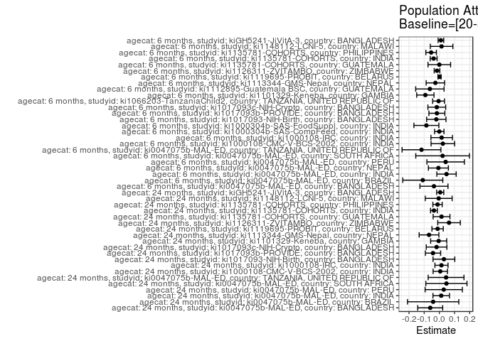

## Results Table

### Parameter: TSM

| agecat | studyid | country | intervention_level | baseline_level | estimate | ci_lower | ci_upper |
| --- | --- | --- | --- | --- | --- | --- | --- |
| 6 months | ki0047075b-MAL-ED | BANGLADESH | [20-30) | NA | -0.1042578 | -0.2593659 | 0.0508502 |
| 6 months | ki0047075b-MAL-ED | BANGLADESH | <20 | NA | -0.0278867 | -0.4618465 | 0.4060731 |
| 6 months | ki0047075b-MAL-ED | BANGLADESH | >=30 | NA | -0.1363992 | -0.4297548 | 0.1569565 |
| 6 months | ki0047075b-MAL-ED | BRAZIL | [20-30) | NA | 1.0809929 | 0.8638897 | 1.2980961 |
| 6 months | ki0047075b-MAL-ED | BRAZIL | <20 | NA | 0.9220718 | 0.5853602 | 1.2587835 |
| 6 months | ki0047075b-MAL-ED | BRAZIL | >=30 | NA | 0.7202840 | 0.3603804 | 1.0801876 |
| 6 months | ki0047075b-MAL-ED | INDIA | [20-30) | NA | -0.7503307 | -0.9002343 | -0.6004272 |
| 6 months | ki0047075b-MAL-ED | INDIA | <20 | NA | -0.6195406 | -0.9176574 | -0.3214237 |
| 6 months | ki0047075b-MAL-ED | INDIA | >=30 | NA | -0.3353320 | -0.6604397 | -0.0102242 |
| 6 months | ki0047075b-MAL-ED | NEPAL | [20-30) | NA | 0.1174775 | -0.0332824 | 0.2682373 |
| 6 months | ki0047075b-MAL-ED | NEPAL | <20 | NA | -0.1990000 | -0.7855073 | 0.3875073 |
| 6 months | ki0047075b-MAL-ED | NEPAL | >=30 | NA | 0.1188768 | -0.1634552 | 0.4012088 |
| 6 months | ki0047075b-MAL-ED | PERU | [20-30) | NA | 1.0130808 | 0.8340494 | 1.1921122 |
| 6 months | ki0047075b-MAL-ED | PERU | <20 | NA | 1.0867581 | 0.8643022 | 1.3092141 |
| 6 months | ki0047075b-MAL-ED | PERU | >=30 | NA | 1.1294726 | 0.8587198 | 1.4002254 |
| 6 months | ki0047075b-MAL-ED | SOUTH AFRICA | [20-30) | NA | 0.5207143 | 0.2772836 | 0.7641451 |
| 6 months | ki0047075b-MAL-ED | SOUTH AFRICA | <20 | NA | 0.6023825 | 0.1636327 | 1.0411324 |
| 6 months | ki0047075b-MAL-ED | SOUTH AFRICA | >=30 | NA | 0.4585708 | 0.2596139 | 0.6575278 |
| 6 months | ki0047075b-MAL-ED | TANZANIA, UNITED REPUBLIC OF | [20-30) | NA | 0.6347897 | 0.4592844 | 0.8102951 |
| 6 months | ki0047075b-MAL-ED | TANZANIA, UNITED REPUBLIC OF | <20 | NA | 0.4266421 | -0.0457594 | 0.8990436 |
| 6 months | ki0047075b-MAL-ED | TANZANIA, UNITED REPUBLIC OF | >=30 | NA | 0.4110963 | 0.2008219 | 0.6213706 |
| 6 months | ki1000108-CMC-V-BCS-2002 | INDIA | [20-30) | NA | -0.5256154 | -0.6950303 | -0.3562005 |
| 6 months | ki1000108-CMC-V-BCS-2002 | INDIA | <20 | NA | -0.4260291 | -0.9385325 | 0.0864742 |
| 6 months | ki1000108-CMC-V-BCS-2002 | INDIA | >=30 | NA | -0.1424037 | -0.5912654 | 0.3064580 |
| 6 months | ki1000108-IRC | INDIA | [20-30) | NA | -0.6141373 | -0.7573749 | -0.4708997 |
| 6 months | ki1000108-IRC | INDIA | <20 | NA | -0.3279587 | -0.8294996 | 0.1735822 |
| 6 months | ki1000108-IRC | INDIA | >=30 | NA | -0.7260211 | -1.4061623 | -0.0458798 |
| 6 months | ki1000304b-SAS-CompFeed | INDIA | [20-30) | NA | -0.6652000 | -0.8228814 | -0.5075187 |
| 6 months | ki1000304b-SAS-CompFeed | INDIA | <20 | NA | -0.5602183 | -0.6476252 | -0.4728114 |
| 6 months | ki1000304b-SAS-CompFeed | INDIA | >=30 | NA | -0.7816169 | -0.9386211 | -0.6246127 |

[output cut: 105 more lines]

### Parameter: E(Y)

| agecat | studyid | country | intervention_level | baseline_level | estimate | ci_lower | ci_upper |
| --- | --- | --- | --- | --- | --- | --- | --- |
| 6 months | ki0047075b-MAL-ED | BANGLADESH | NA | NA | -0.1397960 | -0.2688682 | -0.0107238 |
| 6 months | ki0047075b-MAL-ED | BRAZIL | NA | NA | 0.9717225 | 0.8073791 | 1.1360658 |
| 6 months | ki0047075b-MAL-ED | INDIA | NA | NA | -0.7031481 | -0.8287310 | -0.5775653 |
| 6 months | ki0047075b-MAL-ED | NEPAL | NA | NA | 0.1110452 | -0.0202712 | 0.2423616 |
| 6 months | ki0047075b-MAL-ED | PERU | NA | NA | 1.0543956 | 0.9326967 | 1.1760945 |
| 6 months | ki0047075b-MAL-ED | SOUTH AFRICA | NA | NA | 0.5420735 | 0.3899459 | 0.6942011 |
| 6 months | ki0047075b-MAL-ED | TANZANIA, UNITED REPUBLIC OF | NA | NA | 0.5170513 | 0.3872178 | 0.6468847 |
| 6 months | ki1000108-CMC-V-BCS-2002 | INDIA | NA | NA | -0.5026766 | -0.6536848 | -0.3516685 |
| 6 months | ki1000108-IRC | INDIA | NA | NA | -0.5989297 | -0.7344491 | -0.4634104 |
| 6 months | ki1000304b-SAS-CompFeed | INDIA | NA | NA | -0.6657084 | -0.8024377 | -0.5289791 |
| 6 months | ki1000304b-SAS-FoodSuppl | INDIA | NA | NA | -1.0121579 | -1.1280429 | -0.8962729 |
| 6 months | ki1017093-NIH-Birth | BANGLADESH | NA | NA | -0.4410128 | -0.5302967 | -0.3517289 |
| 6 months | ki1017093b-PROVIDE | BANGLADESH | NA | NA | -0.2083706 | -0.2927992 | -0.1239419 |
| 6 months | ki1017093c-NIH-Crypto | BANGLADESH | NA | NA | 0.0297622 | -0.0491685 | 0.1086930 |
| 6 months | ki1066203-TanzaniaChild2 | TANZANIA, UNITED REPUBLIC OF | NA | NA | 0.0782666 | 0.0252568 | 0.1312764 |
| 6 months | ki1101329-Keneba | GAMBIA | NA | NA | -0.1833795 | -0.2343793 | -0.1323798 |
| 6 months | ki1112895-Guatemala BSC | GUATEMALA | NA | NA | -0.0619988 | -0.1773839 | 0.0533863 |
| 6 months | ki1113344-GMS-Nepal | NEPAL | NA | NA | -0.6047987 | -0.6909649 | -0.5186325 |
| 6 months | ki1119695-PROBIT | BELARUS | NA | NA | 0.5789633 | 0.5190130 | 0.6389137 |
| 6 months | ki1126311-ZVITAMBO | ZIMBABWE | NA | NA | 0.3044096 | 0.2782992 | 0.3305201 |
| 6 months | ki1135781-COHORTS | GUATEMALA | NA | NA | 0.1940810 | 0.1226351 | 0.2655269 |
| 6 months | ki1135781-COHORTS | INDIA | NA | NA | -0.7119298 | -0.7444861 | -0.6793734 |
| 6 months | ki1135781-COHORTS | PHILIPPINES | NA | NA | -0.2938433 | -0.3352064 | -0.2524802 |
| 6 months | ki1148112-LCNI-5 | MALAWI | NA | NA | 0.4410463 | 0.3615008 | 0.5205919 |
| 6 months | kiGH5241-JiVitA-3 | BANGLADESH | NA | NA | -0.5933575 | -0.6128938 | -0.5738211 |
| 24 months | ki0047075b-MAL-ED | BANGLADESH | NA | NA | -0.8208255 | -0.9429246 | -0.6987264 |
| 24 months | ki0047075b-MAL-ED | BRAZIL | NA | NA | 0.4466272 | 0.2416144 | 0.6516401 |
| 24 months | ki0047075b-MAL-ED | INDIA | NA | NA | -0.9571111 | -1.0731621 | -0.8410602 |
| 24 months | ki0047075b-MAL-ED | PERU | NA | NA | 0.1199005 | -0.0000331 | 0.2398341 |
| 24 months | ki0047075b-MAL-ED | SOUTH AFRICA | NA | NA | 0.4267017 | 0.3074751 | 0.5459283 |
| 24 months | ki0047075b-MAL-ED | TANZANIA, UNITED REPUBLIC OF | NA | NA | 0.0500935 | -0.0748234 | 0.1750103 |
| 24 months | ki1000108-CMC-V-BCS-2002 | INDIA | NA | NA | -0.5571505 | -0.6585247 | -0.4557763 |
| 24 months | ki1000108-IRC | INDIA | NA | NA | -0.7458150 | -0.8368180 | -0.6548120 |
| 24 months | ki1017093-NIH-Birth | BANGLADESH | NA | NA | -0.9097790 | -1.0080462 | -0.8115117 |
| 24 months | ki1017093b-PROVIDE | BANGLADESH | NA | NA | -0.8879412 | -0.9708680 | -0.8050144 |
| 24 months | ki1017093c-NIH-Crypto | BANGLADESH | NA | NA | -0.6103502 | -0.7050157 | -0.5156847 |
| 24 months | ki1101329-Keneba | GAMBIA | NA | NA | -0.8079199 | -0.8550714 | -0.7607684 |
| 24 months | ki1113344-GMS-Nepal | NEPAL | NA | NA | -1.1315863 | -1.2192240 | -1.0439487 |
| 24 months | ki1119695-PROBIT | BELARUS | NA | NA | 0.6863435 | 0.5745700 | 0.7981170 |
| 24 months | ki1126311-ZVITAMBO | ZIMBABWE | NA | NA | -1.1830569 | -1.2831570 | -1.0829568 |
| 24 months | ki1135781-COHORTS | GUATEMALA | NA | NA | -0.2813755 | -0.3354674 | -0.2272835 |
| 24 months | ki1135781-COHORTS | INDIA | NA | NA | -0.6627749 | -0.6962103 | -0.6293395 |
| 24 months | ki1135781-COHORTS | PHILIPPINES | NA | NA | -0.6099592 | -0.6467541 | -0.5731643 |
| 24 months | ki1148112-LCNI-5 | MALAWI | NA | NA | -0.0116486 | -0.1020399 | 0.0787427 |
| 24 months | kiGH5241-JiVitA-3 | BANGLADESH | NA | NA | -1.2977181 | -1.3209986 | -1.2744376 |

### Parameter: ATE

| agecat | studyid | country | intervention_level | baseline_level | estimate | ci_lower | ci_upper |
| --- | --- | --- | --- | --- | --- | --- | --- |
| 6 months | ki0047075b-MAL-ED | BANGLADESH | [20-30) | [20-30) | 0.0000000 | 0.0000000 | 0.0000000 |
| 6 months | ki0047075b-MAL-ED | BANGLADESH | <20 | [20-30) | 0.0763711 | -0.3846625 | 0.5374047 |
| 6 months | ki0047075b-MAL-ED | BANGLADESH | >=30 | [20-30) | -0.0321413 | -0.3655334 | 0.3012507 |
| 6 months | ki0047075b-MAL-ED | BRAZIL | [20-30) | [20-30) | 0.0000000 | 0.0000000 | 0.0000000 |
| 6 months | ki0047075b-MAL-ED | BRAZIL | <20 | [20-30) | -0.1589211 | -0.5578635 | 0.2400213 |
| 6 months | ki0047075b-MAL-ED | BRAZIL | >=30 | [20-30) | -0.3607089 | -0.7789414 | 0.0575236 |
| 6 months | ki0047075b-MAL-ED | INDIA | [20-30) | [20-30) | 0.0000000 | 0.0000000 | 0.0000000 |
| 6 months | ki0047075b-MAL-ED | INDIA | <20 | [20-30) | 0.1307902 | -0.2035922 | 0.4651725 |
| 6 months | ki0047075b-MAL-ED | INDIA | >=30 | [20-30) | 0.4149988 | 0.0560931 | 0.7739045 |
| 6 months | ki0047075b-MAL-ED | NEPAL | [20-30) | [20-30) | 0.0000000 | 0.0000000 | 0.0000000 |
| 6 months | ki0047075b-MAL-ED | NEPAL | <20 | [20-30) | -0.3164775 | -0.9220510 | 0.2890961 |
| 6 months | ki0047075b-MAL-ED | NEPAL | >=30 | [20-30) | 0.0013993 | -0.3186630 | 0.3214617 |
| 6 months | ki0047075b-MAL-ED | PERU | [20-30) | [20-30) | 0.0000000 | 0.0000000 | 0.0000000 |
| 6 months | ki0047075b-MAL-ED | PERU | <20 | [20-30) | 0.0736774 | -0.2108597 | 0.3582144 |
| 6 months | ki0047075b-MAL-ED | PERU | >=30 | [20-30) | 0.1163918 | -0.2067916 | 0.4395753 |
| 6 months | ki0047075b-MAL-ED | SOUTH AFRICA | [20-30) | [20-30) | 0.0000000 | 0.0000000 | 0.0000000 |
| 6 months | ki0047075b-MAL-ED | SOUTH AFRICA | <20 | [20-30) | 0.0816682 | -0.4198203 | 0.5831567 |
| 6 months | ki0047075b-MAL-ED | SOUTH AFRICA | >=30 | [20-30) | -0.0621435 | -0.3785389 | 0.2542520 |
| 6 months | ki0047075b-MAL-ED | TANZANIA, UNITED REPUBLIC OF | [20-30) | [20-30) | 0.0000000 | 0.0000000 | 0.0000000 |
| 6 months | ki0047075b-MAL-ED | TANZANIA, UNITED REPUBLIC OF | <20 | [20-30) | -0.2081476 | -0.7125527 | 0.2962574 |
| 6 months | ki0047075b-MAL-ED | TANZANIA, UNITED REPUBLIC OF | >=30 | [20-30) | -0.2236935 | -0.4981358 | 0.0507489 |
| 6 months | ki1000108-CMC-V-BCS-2002 | INDIA | [20-30) | [20-30) | 0.0000000 | 0.0000000 | 0.0000000 |
| 6 months | ki1000108-CMC-V-BCS-2002 | INDIA | <20 | [20-30) | 0.0995862 | -0.4399778 | 0.6391502 |
| 6 months | ki1000108-CMC-V-BCS-2002 | INDIA | >=30 | [20-30) | 0.3832117 | -0.0970973 | 0.8635207 |
| 6 months | ki1000108-IRC | INDIA | [20-30) | [20-30) | 0.0000000 | 0.0000000 | 0.0000000 |
| 6 months | ki1000108-IRC | INDIA | <20 | [20-30) | 0.2861786 | -0.2355112 | 0.8078685 |
| 6 months | ki1000108-IRC | INDIA | >=30 | [20-30) | -0.1118838 | -0.8071838 | 0.5834163 |
| 6 months | ki1000304b-SAS-CompFeed | INDIA | [20-30) | [20-30) | 0.0000000 | 0.0000000 | 0.0000000 |
| 6 months | ki1000304b-SAS-CompFeed | INDIA | <20 | [20-30) | 0.1049818 | -0.0301171 | 0.2400807 |
| 6 months | ki1000304b-SAS-CompFeed | INDIA | >=30 | [20-30) | -0.1164169 | -0.2807933 | 0.0479595 |

[output cut: 105 more lines]

### Parameter: PAR

| agecat | studyid | country | intervention_level | baseline_level | estimate | ci_lower | ci_upper |
| --- | --- | --- | --- | --- | --- | --- | --- |
| 6 months | ki0047075b-MAL-ED | BANGLADESH | [20-30) | NA | -0.0355382 | -0.1280635 | 0.0569871 |
| 6 months | ki0047075b-MAL-ED | BRAZIL | [20-30) | NA | -0.1092704 | -0.2411507 | 0.0226098 |
| 6 months | ki0047075b-MAL-ED | INDIA | [20-30) | NA | 0.0471826 | -0.0165691 | 0.1109343 |
| 6 months | ki0047075b-MAL-ED | NEPAL | [20-30) | NA | -0.0064323 | -0.0723020 | 0.0594375 |
| 6 months | ki0047075b-MAL-ED | PERU | [20-30) | NA | 0.0413148 | -0.0822039 | 0.1648336 |
| 6 months | ki0047075b-MAL-ED | SOUTH AFRICA | [20-30) | NA | 0.0213592 | -0.1555330 | 0.1982514 |
| 6 months | ki0047075b-MAL-ED | TANZANIA, UNITED REPUBLIC OF | [20-30) | NA | -0.1177385 | -0.2457593 | 0.0102824 |
| 6 months | ki1000108-CMC-V-BCS-2002 | INDIA | [20-30) | NA | 0.0229387 | -0.0547567 | 0.1006342 |
| 6 months | ki1000108-IRC | INDIA | [20-30) | NA | 0.0152076 | -0.0557347 | 0.0861499 |
| 6 months | ki1000304b-SAS-CompFeed | INDIA | [20-30) | NA | -0.0005084 | -0.0315057 | 0.0304890 |
| 6 months | ki1000304b-SAS-FoodSuppl | INDIA | [20-30) | NA | -0.0856461 | -0.1678110 | -0.0034811 |
| 6 months | ki1017093-NIH-Birth | BANGLADESH | [20-30) | NA | -0.0201646 | -0.0838709 | 0.0435417 |
| 6 months | ki1017093b-PROVIDE | BANGLADESH | [20-30) | NA | -0.0163402 | -0.0690233 | 0.0363430 |
| 6 months | ki1017093c-NIH-Crypto | BANGLADESH | [20-30) | NA | -0.0169419 | -0.0755644 | 0.0416807 |
| 6 months | ki1066203-TanzaniaChild2 | TANZANIA, UNITED REPUBLIC OF | [20-30) | NA | -0.0050930 | -0.0439248 | 0.0337389 |
| 6 months | ki1101329-Keneba | GAMBIA | [20-30) | NA | -0.0923737 | -0.1492946 | -0.0354529 |
| 6 months | ki1112895-Guatemala BSC | GUATEMALA | [20-30) | NA | -0.0625168 | -0.1559755 | 0.0309418 |
| 6 months | ki1113344-GMS-Nepal | NEPAL | [20-30) | NA | -0.0262338 | -0.0869942 | 0.0345266 |
| 6 months | ki1119695-PROBIT | BELARUS | [20-30) | NA | 0.0011577 | -0.0091012 | 0.0114167 |
| 6 months | ki1126311-ZVITAMBO | ZIMBABWE | [20-30) | NA | -0.0154137 | -0.0339662 | 0.0031387 |
| 6 months | ki1135781-COHORTS | GUATEMALA | [20-30) | NA | -0.0003742 | -0.0747996 | 0.0740512 |
| 6 months | ki1135781-COHORTS | INDIA | [20-30) | NA | -0.0376934 | -0.0603395 | -0.0150473 |
| 6 months | ki1135781-COHORTS | PHILIPPINES | [20-30) | NA | -0.0542009 | -0.0890537 | -0.0193481 |
| 6 months | ki1148112-LCNI-5 | MALAWI | [20-30) | NA | 0.0146434 | -0.0597999 | 0.0890867 |
| 6 months | kiGH5241-JiVitA-3 | BANGLADESH | [20-30) | NA | 0.0102789 | -0.0082827 | 0.0288405 |
| 24 months | ki0047075b-MAL-ED | BANGLADESH | [20-30) | NA | -0.0601962 | -0.1423976 | 0.0220052 |
| 24 months | ki0047075b-MAL-ED | BRAZIL | [20-30) | NA | -0.0409005 | -0.2099263 | 0.1281253 |
| 24 months | ki0047075b-MAL-ED | INDIA | [20-30) | NA | 0.0123732 | -0.0420414 | 0.0667878 |
| 24 months | ki0047075b-MAL-ED | PERU | [20-30) | NA | 0.0289101 | -0.0938610 | 0.1516812 |
| 24 months | ki0047075b-MAL-ED | SOUTH AFRICA | [20-30) | NA | 0.0464978 | -0.0892046 | 0.1822003 |
| 24 months | ki0047075b-MAL-ED | TANZANIA, UNITED REPUBLIC OF | [20-30) | NA | 0.0442970 | -0.0737571 | 0.1623511 |
| 24 months | ki1000108-CMC-V-BCS-2002 | INDIA | [20-30) | NA | 0.0060693 | -0.0411384 | 0.0532771 |
| 24 months | ki1000108-IRC | INDIA | [20-30) | NA | 0.0139292 | -0.0293096 | 0.0571681 |
| 24 months | ki1017093-NIH-Birth | BANGLADESH | [20-30) | NA | 0.0300760 | -0.0416612 | 0.1018133 |
| 24 months | ki1017093b-PROVIDE | BANGLADESH | [20-30) | NA | -0.0417649 | -0.0920782 | 0.0085485 |
| 24 months | ki1017093c-NIH-Crypto | BANGLADESH | [20-30) | NA | -0.0184049 | -0.0863594 | 0.0495495 |
| 24 months | ki1101329-Keneba | GAMBIA | [20-30) | NA | -0.0046087 | -0.0576057 | 0.0483884 |
| 24 months | ki1113344-GMS-Nepal | NEPAL | [20-30) | NA | -0.0682700 | -0.1332408 | -0.0032992 |
| 24 months | ki1119695-PROBIT | BELARUS | [20-30) | NA | -0.0116549 | -0.0490175 | 0.0257077 |
| 24 months | ki1126311-ZVITAMBO | ZIMBABWE | [20-30) | NA | 0.0637756 | -0.0106262 | 0.1381773 |
| 24 months | ki1135781-COHORTS | GUATEMALA | [20-30) | NA | 0.0144220 | -0.0409893 | 0.0698333 |
| 24 months | ki1135781-COHORTS | INDIA | [20-30) | NA | -0.0356751 | -0.0581093 | -0.0132409 |
| 24 months | ki1135781-COHORTS | PHILIPPINES | [20-30) | NA | -0.0120532 | -0.0427288 | 0.0186225 |
| 24 months | ki1148112-LCNI-5 | MALAWI | [20-30) | NA | -0.0043990 | -0.0928972 | 0.0840992 |
| 24 months | kiGH5241-JiVitA-3 | BANGLADESH | [20-30) | NA | 0.0056323 | -0.0177475 | 0.0290121 |